# Вероятности и Статистика Домашно 2 Владимир Ананиев, 81459

**Зад. 1** Таблицата ‘morley’ съдържа резултатите от пет експеримента за измерване на скоростта на светлината. Как са разпределени данните в четвъртия експеримент? Постройте 97% доверителен интервал по данните от него.

```r
#library(UsingR)
#attach(morley)
morley
```

|  | Expt | Run | Speed |
| --- | --- | --- | --- |
| 001 | 1 | 1 | 850 |
| 002 | 1 | 2 | 740 |
| 003 | 1 | 3 | 900 |
| 004 | 1 | 4 | 1070 |
| 005 | 1 | 5 | 930 |
| 006 | 1 | 6 | 850 |
| 007 | 1 | 7 | 950 |
| 008 | 1 | 8 | 980 |
| 009 | 1 | 9 | 980 |
| 010 | 1 | 10 | 880 |

[output cut: 90 more lines]

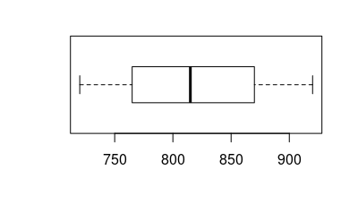

```r
fourth <- morley[Expt == 4,]
speed = fourth$Speed
boxplot(speed, horizontal = T)
```

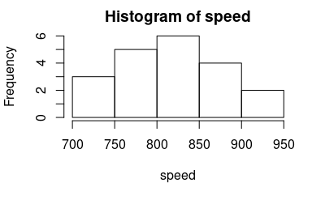

```r
hist(speed)
```

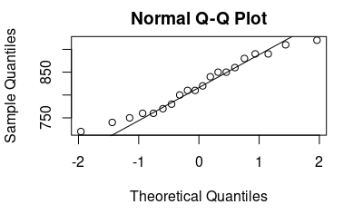

```r
qqnorm(speed)
qqline(speed)
```

> Данните изглеждат нормално разпредени, ще направим Shapiro-Wilk тест за нормалност

```r
shapiro.test(speed)
```

```
    Shapiro-Wilk normality test

data:  speed
W = 0.96113, p-value = 0.5667
```

> p-value > 0.5. Приемаме,че данните са нормално разпределени

```r
t.test(speed, conf.int = TRUE, conf.level=0.97)
```

```
    One Sample t-test

data:  speed
t = 61.114, df = 19, p-value < 2.2e-16
alternative hypothesis: true mean is not equal to 0
97 percent confidence interval:
 789.008 851.992
sample estimates:
mean of x
    820.5
```

> 97% Confidence Interval: [789.008 - 851.992]

**Зад. 2** Тества се ново лекарство за отслабване. Наблюдавани са 10 мишки, теглото им преди е било: *255, 258, 256, 201, 215, 207, 213, 215, 242, 216*, след употребата на лекарството е: *250, 263, 254, 200, 213, 200, 210, 211, 232, 210*. Вярно ли е, че лекарството води до отслабване?

> От теглото им преди изваждаме теглото след приемане на лекарството  
> H0: m >= 0  
> H1: m < 0

```r
x = c(255, 258, 256, 201, 215, 207, 213, 215, 242, 216)
y = c(250, 263, 254, 200, 213, 200, 210, 211, 232, 210)
shapiro.test(x - y)
```

```
    Shapiro-Wilk normality test

data:  x - y
W = 0.95777, p-value = 0.7602
```

> p-value > 0.05 => Данните са нормално разпределени

```r
### ??????
#wilcox.test(y, x, alternative='')
t.test(x - y, m=0, alternative = 'less')
```

```
    One Sample t-test

data:  x - y
t = 2.7433, df = 9, p-value = 0.9886
alternative hypothesis: true mean is less than 0
95 percent confidence interval:
     -Inf 5.838766
sample estimates:
mean of x
      3.5
```

> p-value > 0.05 => приемаме H0 и лекарството води до отслабване

**Зад. 3** По данните ‘birthwt’ от пакета ‘MASS’, можем ли да твърдим, че има връзка между тютюнопушененто и раждането на бебе под нормалните (2.5) кг? Проверете графично. Формулирайте и проверете хипотеза за това твърдение.

```r
birthwt
```

|  | low | age | lwt | race | smoke | ptl | ht | ui | ftv | bwt |
| --- | --- | --- | --- | --- | --- | --- | --- | --- | --- | --- |
| 85 | 0 | 19 | 182 | 2 | 0 | 0 | 0 | 1 | 0 | 2523 |
| 86 | 0 | 33 | 155 | 3 | 0 | 0 | 0 | 0 | 3 | 2551 |
| 87 | 0 | 20 | 105 | 1 | 1 | 0 | 0 | 0 | 1 | 2557 |
| 88 | 0 | 21 | 108 | 1 | 1 | 0 | 0 | 1 | 2 | 2594 |
| 89 | 0 | 18 | 107 | 1 | 1 | 0 | 0 | 1 | 0 | 2600 |
| 91 | 0 | 21 | 124 | 3 | 0 | 0 | 0 | 0 | 0 | 2622 |
| 92 | 0 | 22 | 118 | 1 | 0 | 0 | 0 | 0 | 1 | 2637 |
| 93 | 0 | 17 | 103 | 3 | 0 | 0 | 0 | 0 | 1 | 2637 |
| 94 | 0 | 29 | 123 | 1 | 1 | 0 | 0 | 0 | 1 | 2663 |
| 95 | 0 | 26 | 113 | 1 | 1 | 0 | 0 | 0 | 0 | 2665 |

[output cut: 179 more lines]

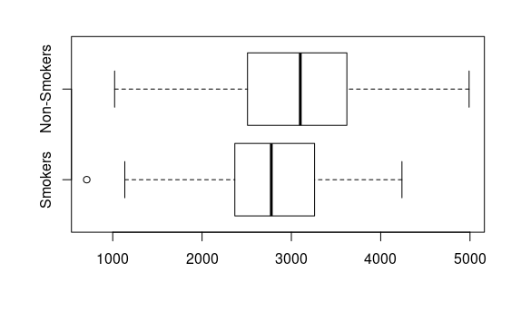

```r
smoker_babies = bwt[smoke >= 1]
non_smoker_babies = bwt[smoke == 0]
boxplot(smoker_babies, non_smoker_babies, horizontal = TRUE, names=c('Smokers', 'Non-Smokers'))
```

> Забелязва се, че средното тегло на децата на майките пушачи е по-ниско от това на непушачите. Също максималните стойности при майките непушачи достигат 5кг, докато при майките пушачи това е само 4.2кг. За бебетата под нормалните колограми се забелязва, че при пушачите има outlier доста под 1кг. Нека разгледаме данните само за бебетата под 2.5кг

```r
no_sm = birthwt[smoke == 0 & bwt < 2500, 'bwt']
length(no_sm)
```

```
[1] 29
```

```r
sm = birthwt[smoke == 1 & bwt < 2500, 'bwt']
length(sm)
```

```
[1] 30
```

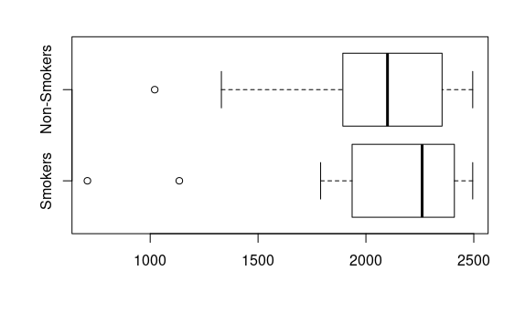

```r
boxplot(sm, no_sm, horizontal = TRUE, names=c('Smokers', 'Non-Smokers'))
```

> Броят бебета за двете групи е приблизително еднакъв. 29 за непушачи и 30 за пушачи.

**Зад. 4** Променливите *X1,…,X6* са във файл “DataR2.txt” Използвайте графични методи за да определите типа на реазпределението на всяка от тях - нормално, равномерно, експоненциално, друго. Между кои две променливи съществува най-силно изразена линейна зависимост? Проверете хипотеза, че свободния член *β<sub>0</sub>* е равен на 1.